# Lab Week 2

STAT5003

Dr. Justin Wishart

### Preparation and assumed knowledge

- Linear regression models covered in Module 2 content.

### Aims

- Implementation of a linear regression using the `lm` function.
- Interpret the output of a linear model.
- Improve an existing linear model.
- Communicate your results.

# 1 Melbourne house prices regression model

In this section we will examine the dataset describing Melbourne house prices. This dataset was downloaded from [Kaggle](https://www.kaggle.com/anthonypino/melbourne-housing-market) and the data was released under the CC BY-NC-SA 4.0 license. For this lab, we will focus on three subrubs - Brunswick, Craigieburn and Hawthorn and examine what variables or factors are associated with the housing price.

## 1.1 Load the data

Load the Melbourne house price dataset from Canvas.

**Solution**

```r
melbdata <- read.csv("Melbourne_housing_FULL.csv", header = TRUE, stringsAsFactors = TRUE)
```

## 1.2 Initial data analysis

We will need to subset the data to only look at 3 suburbs - Brunswick, Craigieburn and Hawthorn. Similar to lab 1, start the data analysis by generating some quantitative and graphical summaries. For example, determine the average price in each of these three suburbs. Explore more summaries of the data.

**Solution**

```r
melbdata.sub <- subset(melbdata, Suburb == "Hawthorn" | Suburb == "Brunswick" | Suburb == "Craigieburn")
hawthorn <- subset(melbdata.sub, Suburb == "Hawthorn")
# Or use the %in% operator
# This operator has usage x %in% y
# where each element of x is checked to see if it appears # any element of y
melbdata.sub2 <- subset(melbdata, Suburb %in% c("Hawthorn", "Brunswick", "Craigieburn"))
# The methods are equivalent
identical(melbdata.sub, melbdata.sub2)
```

```
## [1] TRUE
```

```r
# Checking the means of each suburb can be done many ways
# Two shown below, aggregate, by and an apply way
aggregate(Price ~ Suburb, data = melbdata.sub, mean)
```

```
##        Suburb     Price
## 1   Brunswick  977988.8
## 2 Craigieburn  566173.5
## 3    Hawthorn 1238074.2
```

```r
head(with(melbdata.sub, by(Price, Suburb, mean, na.rm = TRUE)))
```

```
## Suburb
##   Abbotsford   Aberfeldie Airport West    Albanvale  Albert Park       Albion
##           NA           NA           NA           NA           NA           NA
```

```r
# Notice how it wants to compute means for suburbs that
# have been filtered out
# We can fix this by dropping categories that are not observed in the data.frame
melbdata.sub <- droplevels(melbdata.sub)
with(melbdata.sub, by(Price, Suburb, mean, na.rm = TRUE))
```

```
## Suburb: Brunswick
## [1] 977988.8
## ------------------------------------------------------------
## Suburb: Craigieburn
## [1] 566173.5
## ------------------------------------------------------------
## Suburb: Hawthorn
## [1] 1238074
```

```r
prices.by.suburb <- with(melbdata.sub, split(Price, Suburb))
sapply(prices.by.suburb, mean, na.rm = TRUE)
```

```
##   Brunswick Craigieburn    Hawthorn
##    977988.8    566173.5   1238074.2
```

```r
## Tidyverse way, use filter, group_by and summarise
library(tidyverse)
melbdata %>%
  dplyr::filter(Suburb %in% c("Hawthorn", "Brunswick", "Craigieburn")) %>%
  group_by(Suburb) %>%
  summarise(`Mean Price` = mean(Price, na.rm = TRUE))
```

```
## # A tibble: 3 x 2
##   Suburb      `Mean Price`
##   <fct>              <dbl>
## 1 Brunswick        977989.
## 2 Craigieburn      566173.
## 3 Hawthorn        1238074.
```

For the following questions, use the subsetted data for the Suburbs of Brunswick, Craigieburn and Hawthorn.

## 1.3 Finding association I

To examine the association between house prices and a single variable, start by constructing a simple linear regression using only `BuildingArea` as a predictor. Use an appropriate statistic to justify the goodness of fit of the prediction and create a graphical output to enable you to assess your model fit.

Note: you might consider other variables too.

**Solution** Consider a scatter plot of `Price` against `BuildingArea` and overlay the prediction from the linear regression model.

```r
lmfit1 <- lm(data = melbdata.sub, Price/1000 ~ BuildingArea)
summary(lmfit1)
```

```
##
## Call:
## lm(formula = Price/1000 ~ BuildingArea, data = melbdata.sub)
##
## Residuals:
##     Min      1Q  Median      3Q     Max
## -3421.8  -463.9  -148.0   259.1  6052.4
##
## Coefficients:
##              Estimate Std. Error t value Pr(>|t|)
## (Intercept)  518.1921    66.5956   7.781 5.74e-14 ***
## BuildingArea   3.8007     0.4082   9.311  < 2e-16 ***
## ---
## Signif. codes:  0 '***' 0.001 '**' 0.01 '*' 0.05 '.' 0.1 ' ' 1
##
## Residual standard error: 730 on 416 degrees of freedom
##   (709 observations deleted due to missingness)
## Multiple R-squared:  0.1725, Adjusted R-squared:  0.1705
## F-statistic: 86.69 on 1 and 416 DF,  p-value: < 2.2e-16
```

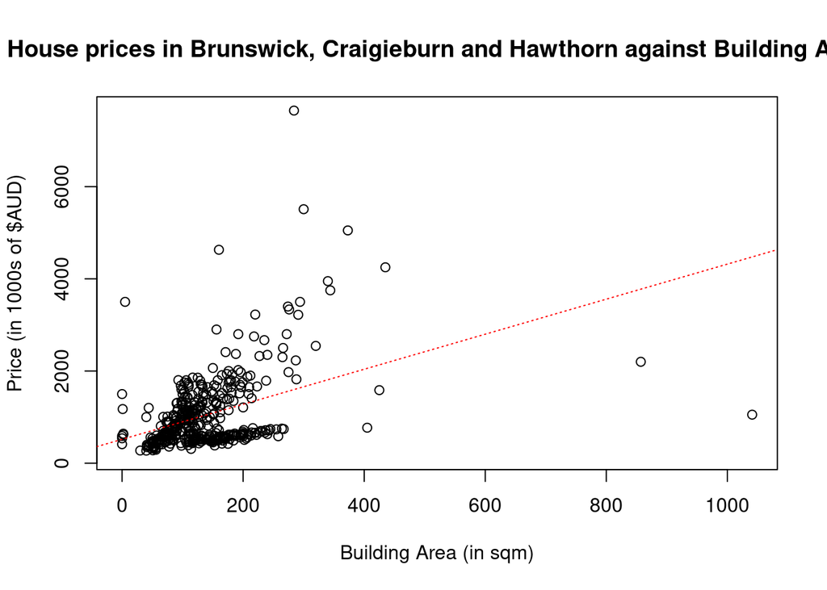

```r
plot(Price/1000 ~ BuildingArea, data = melbdata.sub,
     main = "House prices in Brunswick, Craigieburn and Hawthorn against Building Area",
     xlab = "Building Area (in sqm)", ylab = "Price (in 1000s of $AUD)")
abline(lmfit1, col = "red", lty = "dotted")
```

The Goodness of fit statistic is 0.1725 which implies that 17.25% of the variation in `Price` is explained by the linear regression on `BuildingArea`

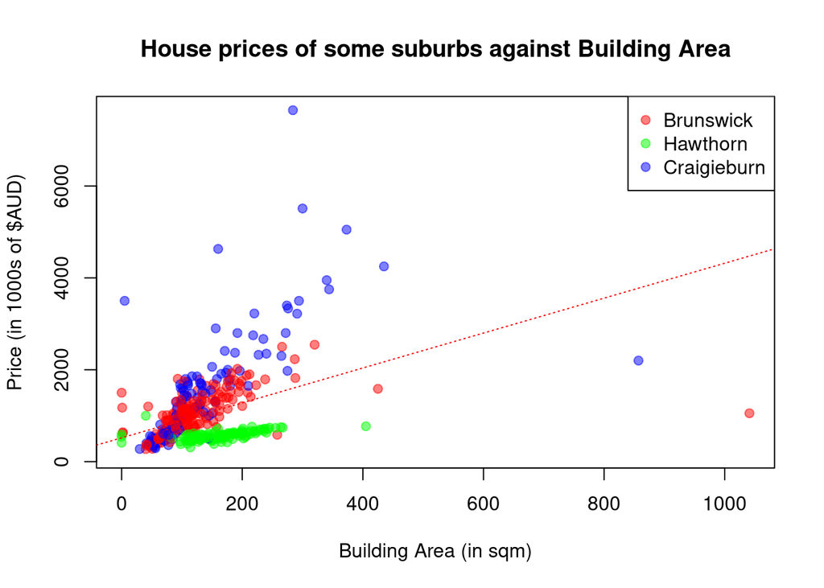

```r
lmfit1 <- lm(data = melbdata.sub, Price/1000 ~ BuildingArea)
# Get semi-transparent red green and blue
my.colours <- rgb(c(1, 0, 0), c(0, 1, 0), c(0, 0, 1), alpha = 0.5)
plot(Price/1000 ~ BuildingArea, data = melbdata.sub,
     main = "House prices of some suburbs against Building Area",
     xlab = "Building Area (in sqm)", ylab = "Price (in 1000s of $AUD)",
     col = my.colours[as.integer(melbdata.sub[["Suburb"]])],
     pch = 19)
legend("topright", legend = unique(melbdata.sub[["Suburb"]]),
       col = my.colours, pch = 19)
abline(lmfit1, col = "red", lty = "dotted")
```

```r
r2 <- round(summary(lmfit1)$r.squared, 4)
```

## 1.4 Finding association II

1. Variability of house prices are complex and likely to be explained by many different factors. Construct a multiple linear regression here by examining if adding `Suburb` as a predictor will improve the prediction? Notice that `Suburb` is a categorical variable. Briefly describe how to interpret the regression coefficients returned by `lm`.
2. There are many other variables in the data, you might consider whether adding the number of car spaces as a predictor improve the prediction model?

**Solution**

1. Model fit below

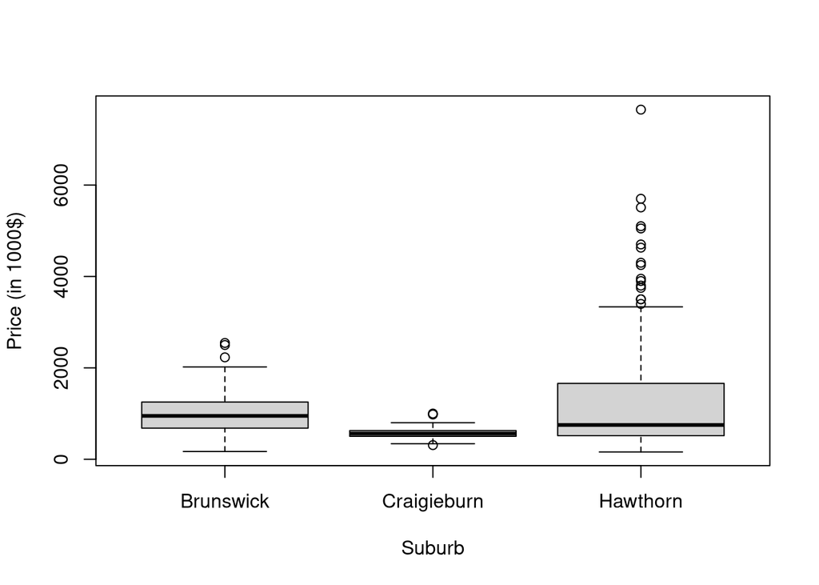

```r
boxplot(Price/1000 ~ Suburb, data = melbdata.sub, ylab = "Price (in 1000$)", xlab = "Suburb")
```

```r
lmfit2 <- lm(data = melbdata.sub, Price/1000 ~ BuildingArea + Suburb)
coefs <- lmfit2$coefficients
invisible(lapply(unique(melbdata.sub$Suburb), function(x) {
    plot(Price/1000 ~ BuildingArea, data = subset(melbdata.sub, Suburb == x), main = x,
         xlab = "Building Area (in sqm)", ylab = "Price (in 1000s of $AUD)")
    int <- coefs[1]
    if (any(adjust.ind <- grepl(paste0(x, "$"), names(coefs))))
        int <- int + coefs[adjust.ind]
    abline(int, coefs[2])
}))
summary(lmfit2)
```

```
##
## Call:
## lm(formula = Price/1000 ~ BuildingArea + Suburb, data = melbdata.sub)
##
## Residuals:
##     Min      1Q  Median      3Q     Max
## -4074.1  -248.5   -26.7   166.0  5479.9
##
## Coefficients:
##                    Estimate Std. Error t value Pr(>|t|)
## (Intercept)        509.7567    62.4510   8.163 3.99e-15 ***
## BuildingArea         4.4354     0.3469  12.786  < 2e-16 ***
## SuburbCraigieburn -660.2773    72.9115  -9.056  < 2e-16 ***
## SuburbHawthorn     400.7159    72.5435   5.524 5.87e-08 ***
## ---
## Signif. codes:  0 '***' 0.001 '**' 0.01 '*' 0.05 '.' 0.1 ' ' 1
##
## Residual standard error: 609.9 on 414 degrees of freedom
##   (709 observations deleted due to missingness)
## Multiple R-squared:  0.425,  Adjusted R-squared:  0.4208
## F-statistic:   102 on 3 and 414 DF,  p-value: < 2.2e-16
```

```r
r2s <- summary(lmfit2)$r.squared
```

[figure not shown]

One way to highlight that the regression lines for the three suburbs are parallel is to put all three on the same graph, as follows.

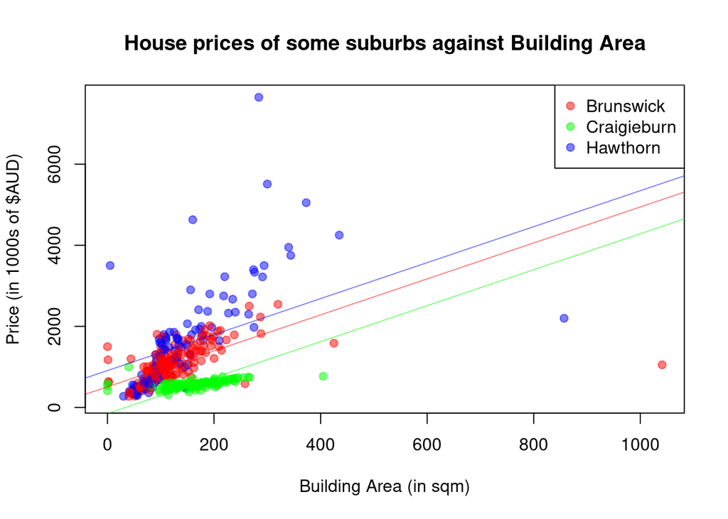

```r
plot(Price/1000 ~ BuildingArea, data = melbdata.sub,
     main = "House prices of some suburbs against Building Area",
     xlab = "Building Area (in sqm)", ylab = "Price (in 1000s of $AUD)",
     col = my.colours[as.integer(melbdata.sub[["Suburb"]])],
     pch = 19)
legend("topright", legend = levels(melbdata.sub[["Suburb"]]),
       col = my.colours, pch = 19)
coefs <- coefficients(lmfit2)
names(my.colours) <- levels(melbdata.sub$Suburb)
r2 <- round(summary(lmfit1)$r.squared, 4)
  lapply(levels(melbdata.sub$Suburb), function(x) {
    int <- coefs[1]
    if (any(adjust.ind <- endsWith(names(coefs), x)))
        int <- int + coefs[adjust.ind]
    abline(a = int, b = coefs[2], col = my.colours[x])
  })
```

### 1.4.1 Embedding model fit in ggplot

`ggplot` includes a really clever trick to support easily constructing line fits (smoothed or linear or …) however the interactions between the model specification and the plotting specification can be subtle, resulting in graphs that do not match the numerical analysis, which are then at best misleading.

An example of fitting different models.

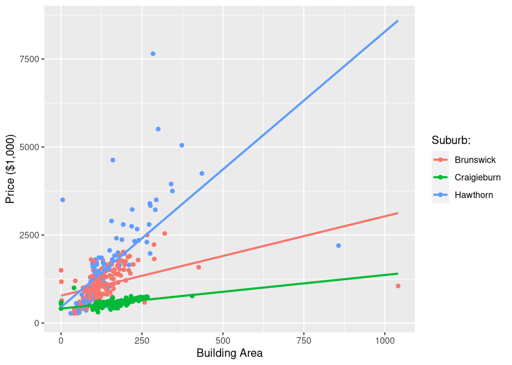

```r
library(ggplot2)
ggplot(melbdata.sub, aes(x = BuildingArea, y = Price/1000, color=Suburb)) +
  geom_point(na.rm = TRUE) +
  geom_smooth(formula="y~x", method = "lm", se = FALSE, fullrange=TRUE, na.rm = TRUE) +
  xlab("Building Area") + ylab("Price ($1,000)") + labs(colour="Suburb:")
```

Specifying the colour slightly differently, results in a different model!

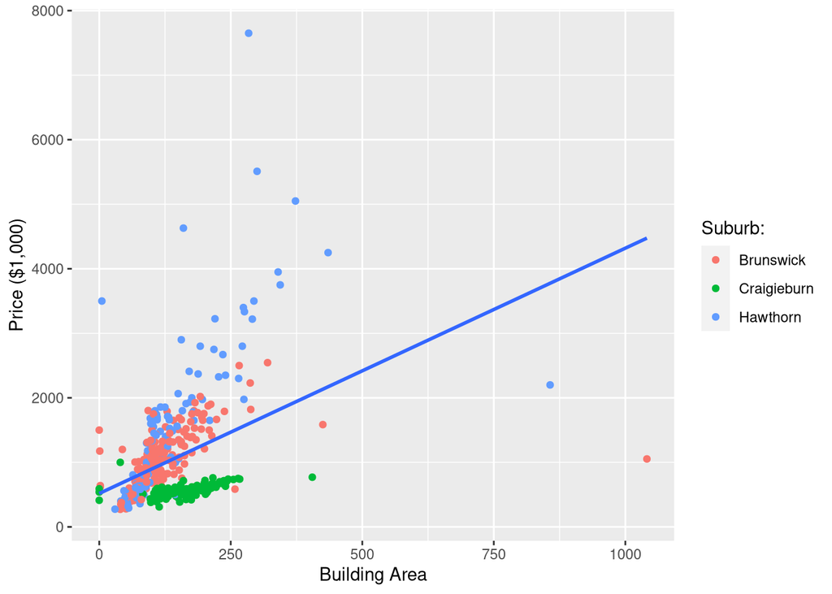

```r
ggplot(melbdata.sub, aes(x = BuildingArea, y = Price/1000)) +
  geom_point(aes(color=Suburb), na.rm = TRUE) +
  geom_smooth(formula="y~x", method = "lm", se = FALSE, fullrange=TRUE, na.rm = TRUE) +
  xlab("Building Area") + ylab("Price ($1,000)") + labs(colour="Suburb:")
```

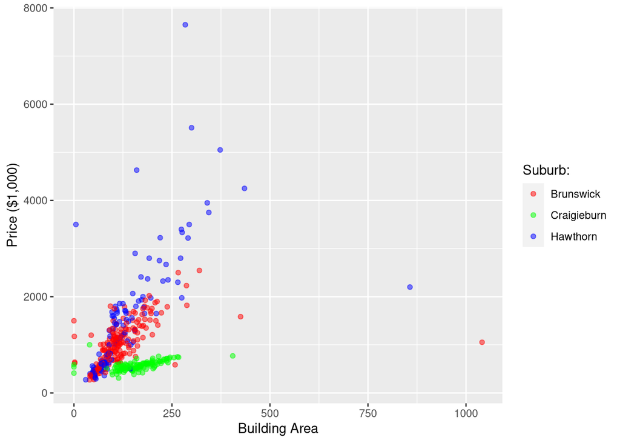

```r
# reuse previous color key
colScale <- scale_colour_manual(name = "Suburb:", values = my.colours) # name is used as legend title
ggplot(melbdata.sub, aes(x = BuildingArea, y = Price/1000, col = Suburb) ) +
  geom_point(na.rm = TRUE) +
  xlab("Building Area") + ylab("Price ($1,000)") + colScale +
  sapply(unique(melbdata.sub$Suburb_f), function(x) {
       int <- coefs[1]
       if (any(adjust.ind <- grepl(paste0(x, "$"), names(coefs))))
           int <- int + coefs[adjust.ind]
       geom_abline( intercept=int, slope=coefs[2], col=my.colours[x] )
    })
```

### 1.4.2 Commentary on Models

The `Suburb` predictor improves the fit of the model by increasing the $R^2$ from 0.1725 to 0.4249986. However, the adjusted $R^2$ is amore appropriate goodness of fit measure when there is more than one predictor in the model since adding another predictor will always increase the $R^2$. In this case the adjusted $R^2$ increases by a similar amount suggesting Suburb is a good additional predictor.

Interpreting the `BuildingArea` slope has the interpretation that for each unit increase in square meter of building size, the expected average price would increase by $4435. Interpreting the categorical predictors needs to be done by intercept adjustment. The first categorical level of `Suburb` (Brunswick) becomes the baseline intercept and the other suburbs are adjusted against the baseline intercept. In this case Craigieburn and Hawthorn have adjustments of -660,000 and 400,000 respectively. This should be interpretted that properties in Craigieburn are $660,000 cheaper than Brunswick on average (if BuildingArea is held fixed). Hawthorn properties are $400,000 more expensive than Brunswick. This is consistent with the graphical summary in the boxplot which indicates without adjusting for Building Area, Craigie burn tends to have cheaper houses with low variance while Hawthorn has a large variance in house prices with many very expensive outlying properties.

2. Adding the number of car spaces in to the model and compare the goodness of fit measures.

```r
lmfit4 <- lm(data = melbdata.sub, Price ~ BuildingArea + Suburb + Car)
summary(lmfit4)
```

```
##
## Call:
## lm(formula = Price ~ BuildingArea + Suburb + Car, data = melbdata.sub)
##
## Residuals:
##      Min       1Q   Median       3Q      Max
## -3417281  -273352   -59191   252474  5001704
##
## Coefficients:
##                    Estimate Std. Error t value Pr(>|t|)
## (Intercept)        333560.7    67011.4   4.978 9.56e-07 ***
## BuildingArea         3761.7      351.3  10.708  < 2e-16 ***
## SuburbCraigieburn -781107.7    73776.4 -10.588  < 2e-16 ***
## SuburbHawthorn     363436.8    71139.5   5.109 5.02e-07 ***
## Car                220740.5    34616.8   6.377 4.98e-10 ***
## ---
## Signif. codes:  0 '***' 0.001 '**' 0.01 '*' 0.05 '.' 0.1 ' ' 1
##
## Residual standard error: 588500 on 402 degrees of freedom
##   (720 observations deleted due to missingness)
## Multiple R-squared:  0.477,  Adjusted R-squared:  0.4718
## F-statistic: 91.66 on 4 and 402 DF,  p-value: < 2.2e-16
```

Adding car spaces seems to improve the prediction model if `BuildingArea` and `Suburb` are already included in the model. The goodness of fit metrics (both raw and adjusted) increase.

## 1.5 Impact of outliers

**Solution** A simple strategy to assess the impact of outliers is to remove the outliers and see if you can improve the prediction model.

```
##
## Call:
## lm(formula = Price/1000 ~ BuildingArea + Suburb, data = melbdata.sub.2)
##
## Residuals:
##     Min      1Q  Median      3Q     Max
## -1658.0  -260.8   -30.5   192.6  4895.4
##
## Coefficients:
##                    Estimate Std. Error t value Pr(>|t|)
## (Intercept)         38.4036    60.2651   0.637    0.524
## BuildingArea         8.5448     0.4234  20.180  < 2e-16 ***
## SuburbCraigieburn -870.8069    56.3822 -15.445  < 2e-16 ***
## SuburbHawthorn     289.4724    53.9824   5.362  1.4e-07 ***
## ---
## Signif. codes:  0 '***' 0.001 '**' 0.01 '*' 0.05 '.' 0.1 ' ' 1
##
## Residual standard error: 442.6 on 396 degrees of freedom
##   (81 observations deleted due to missingness)
## Multiple R-squared:  0.5984, Adjusted R-squared:  0.5954
## F-statistic: 196.7 on 3 and 396 DF,  p-value: < 2.2e-16
```

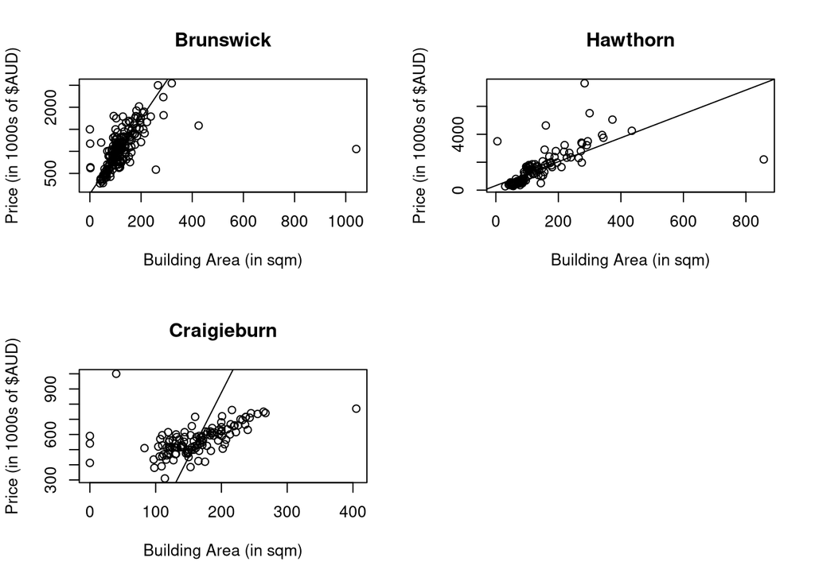

```r
melbdata.sub.2 <- subset(melbdata.sub, BuildingArea > 10 & BuildingArea < 300)
lmfit3 <- lm(data = melbdata.sub.2, Price/1000 ~ BuildingArea + Suburb)
coefs <- lmfit3$coefficients
par(mfrow = c(2, 2))
invisible(lapply(unique(melbdata.sub$Suburb), function(x) {
    plot(Price/1000 ~ BuildingArea, data = subset(melbdata.sub, Suburb == x), main = x,
         xlab = "Building Area (in sqm)", ylab = "Price (in 1000s of $AUD)")
    int <- coefs[1]
    if (any(adjust.ind <- grepl(paste0(x, "$"), names(coefs))))
        int <- int + coefs[adjust.ind]
    abline(int, coefs[2])
}))
summary(lmfit3)
```

Removing the outliers does improve the fit of the model as the overall residual standard error has decreased and the goodness of fit metrics have increased to around 0.6. Also visually we can see an improved fit for Hawthorn and Brunswick. Although there still is a poor fit for Cragieburn

## 1.6 Prediction

Predict the price of a house in Hawthorn with 2 car spaces and 100 sqm in building area. What is the 95% confidence interval of your prediction value?

**Solution**

```r
predict(lmfit4, data.frame(Suburb = "Hawthorn", BuildingArea = 100, Car = 2), interval = "confidence")
```

```
##       fit     lwr     upr
## 1 1514653 1393868 1635439
```

If using the model in question 1.4, then the predicted value for an average property with those features would be $1,514,653.

# 2 Shiny app of a regression

Construct an app that takes the housing data and allows the user to select the suburbs and variables in the model and displays the `summary` output, and plot the data.

In the tutorial class, consider some strategies to design a shiny app to communicate the results of a regression like this effectively.

**Solution**

## 2.1 UI code

```r
melbdata.names <- colnames(melbdata)
# Remove variables that wont make since in this context (nor in regression)
# variables <- melbdata.names[!melbdata.names %in% c("Suburb", "Address", "Date", "Price")]
variables <- melbdata.names[!melbdata.names %in% c( "Address", "Date", "Price")]
selectInput("suburbs", "Choose suburbs to model:",
            choices = unique(melbdata[["Suburb"]]),
            multiple = TRUE)
selectInput("variables", "Choose regression variables",
            choices = variables,
            multiple = TRUE,
            selected = "BuildingArea")
```

```r
tabsetPanel(type = "pills",
            tabPanel("Summary", verbatimTextOutput("regression.summary")),
            tabPanel("Variable Scatter", plotOutput("scatterplot")))
```

## 2.2 Server code

```r
library(tidyverse)
library(GGally)
dat <- reactive({
  melbdata  %>%
    dplyr::filter(Suburb %in% input$suburbs) %>%
    select(any_of(c("Price", input$variables))) %>%
    drop_na
})
regression.formula <- reactive({
    as.formula(paste0("Price ~ ", paste0(input$variables, collapse = " + "), collapse = ""))
})
regression.model <- reactive({
  lm(formula(regression.formula()), data = dat())
})
output$scatterplot <- renderPlot({
  validate(
      need(input$suburbs, 'Choose at least one Suburb'),
      need(input$variables, "Choose at least one predictor (feature)")
    )
  dat() %>% ggpairs(.)
})
output$regression.summary <- renderPrint({
    validate(
      need(input$suburbs, 'Choose at least one Suburb'),
      need(input$variables, "Choose at least one predictor (feature)")
    )
    summary(regression.model())
})
```

```r
library(tidyverse)
library(GGally)
dat <- reactive({
  melbdata  %>%
    dplyr::filter(Suburb %in% input$suburbs) %>%
    select(any_of(c("Price", input$variables))) %>%
    drop_na
})
regression.formula <- reactive({
    as.formula(paste0("Price ~ ", paste0(input$variables, collapse = " + "), collapse = ""))
})
regression.model <- reactive({
  lm(formula(regression.formula()), data = dat())
})
output$scatterplot <- renderPlot({
  validate(
      need(input$suburbs, 'Choose at least one Suburb'),
      need(input$variables, "Choose at least one predictor (feature)")
    )
  dat() %>% ggpairs(.)
})
output$regression.summary <- renderPrint({
    validate(
      need(input$suburbs, 'Choose at least one Suburb'),
      need(input$variables, "Choose at least one predictor (feature)")
    )
    summary(regression.model())
})
```